# Risk Factor Analysis

## Outcome Variable

**Outcome Variable:** pers_wast

## Predictor Variables

**Intervention Variable:** exclfeed6

**Adjustment Set:**

- arm
- sex
- brthmon
- W_mage
- meducyrs
- feducyrs
- hhwealth_quart
- hfoodsec
- W_mhtcm
- W_mwtkg
- W_mbmi
- vagbrth
- W_gagebrth
- W_birthwt
- W_birthlen
- W_nrooms
- W_nchldlt5
- month
- W_parity
- impfloor
- impsan
- safeh20
- delta_W_mage
- delta_meducyrs
- delta_feducyrs
- delta_hhwealth_quart
- delta_hfoodsec
- delta_W_mhtcm
- delta_W_mwtkg
- delta_W_mbmi
- delta_vagbrth
- delta_W_gagebrth
- delta_W_birthwt
- delta_W_birthlen
- delta_W_nrooms
- delta_W_nchldlt5
- delta_month
- delta_W_parity
- delta_impfloor
- delta_impsan
- delta_safeh20

## Stratifying Variables

The analysis was stratified on these variable(s):

- agecat
- studyid
- country

## Data Summary

| agecat | studyid | country | exclfeed6 | pers_wast | n_cell | n |
| --- | --- | --- | --- | --- | --- | --- |
| 0-24 months | CMC-V-BCS-2002 | INDIA | 1 | 0 | 19 | 19 |
| 0-24 months | CMC-V-BCS-2002 | INDIA | 1 | 1 | 0 | 19 |
| 0-24 months | CMC-V-BCS-2002 | INDIA | 0 | 0 | 0 | 19 |
| 0-24 months | CMC-V-BCS-2002 | INDIA | 0 | 1 | 0 | 19 |
| 0-24 months | EE | PAKISTAN | 1 | 0 | 42 | 48 |
| 0-24 months | EE | PAKISTAN | 1 | 1 | 1 | 48 |
| 0-24 months | EE | PAKISTAN | 0 | 0 | 5 | 48 |
| 0-24 months | EE | PAKISTAN | 0 | 1 | 0 | 48 |
| 0-24 months | GMS-Nepal | NEPAL | 1 | 0 | 366 | 564 |
| 0-24 months | GMS-Nepal | NEPAL | 1 | 1 | 54 | 564 |
| 0-24 months | GMS-Nepal | NEPAL | 0 | 0 | 121 | 564 |
| 0-24 months | GMS-Nepal | NEPAL | 0 | 1 | 23 | 564 |
| 0-24 months | IRC | INDIA | 1 | 0 | 0 | 14 |
| 0-24 months | IRC | INDIA | 1 | 1 | 0 | 14 |
| 0-24 months | IRC | INDIA | 0 | 0 | 12 | 14 |
| 0-24 months | IRC | INDIA | 0 | 1 | 2 | 14 |
| 0-24 months | JiVitA-3 | BANGLADESH | 1 | 0 | 6847 | 9436 |
| 0-24 months | JiVitA-3 | BANGLADESH | 1 | 1 | 410 | 9436 |
| 0-24 months | JiVitA-3 | BANGLADESH | 0 | 0 | 2054 | 9436 |
| 0-24 months | JiVitA-3 | BANGLADESH | 0 | 1 | 125 | 9436 |
| 0-24 months | JiVitA-4 | BANGLADESH | 1 | 0 | 3366 | 4657 |
| 0-24 months | JiVitA-4 | BANGLADESH | 1 | 1 | 261 | 4657 |
| 0-24 months | JiVitA-4 | BANGLADESH | 0 | 0 | 924 | 4657 |
| 0-24 months | JiVitA-4 | BANGLADESH | 0 | 1 | 106 | 4657 |
| 0-24 months | Keneba | GAMBIA | 1 | 0 | 709 | 2119 |
| 0-24 months | Keneba | GAMBIA | 1 | 1 | 30 | 2119 |
| 0-24 months | Keneba | GAMBIA | 0 | 0 | 1291 | 2119 |
| 0-24 months | Keneba | GAMBIA | 0 | 1 | 89 | 2119 |
| 0-24 months | LCNI-5 | MALAWI | 1 | 0 | 42 | 240 |
| 0-24 months | LCNI-5 | MALAWI | 1 | 1 | 0 | 240 |
| 0-24 months | LCNI-5 | MALAWI | 0 | 0 | 195 | 240 |
| 0-24 months | LCNI-5 | MALAWI | 0 | 1 | 3 | 240 |
| 0-24 months | MAL-ED | BANGLADESH | 1 | 0 | 32 | 233 |
| 0-24 months | MAL-ED | BANGLADESH | 1 | 1 | 1 | 233 |
| 0-24 months | MAL-ED | BANGLADESH | 0 | 0 | 188 | 233 |
| 0-24 months | MAL-ED | BANGLADESH | 0 | 1 | 12 | 233 |
| 0-24 months | MAL-ED | BRAZIL | 1 | 0 | 12 | 210 |
| 0-24 months | MAL-ED | BRAZIL | 1 | 1 | 0 | 210 |
| 0-24 months | MAL-ED | BRAZIL | 0 | 0 | 196 | 210 |
| 0-24 months | MAL-ED | BRAZIL | 0 | 1 | 2 | 210 |
| 0-24 months | MAL-ED | INDIA | 1 | 0 | 2 | 219 |
| 0-24 months | MAL-ED | INDIA | 1 | 1 | 0 | 219 |
| 0-24 months | MAL-ED | INDIA | 0 | 0 | 199 | 219 |
| 0-24 months | MAL-ED | INDIA | 0 | 1 | 18 | 219 |
| 0-24 months | MAL-ED | NEPAL | 1 | 0 | 5 | 225 |
| 0-24 months | MAL-ED | NEPAL | 1 | 1 | 0 | 225 |
| 0-24 months | MAL-ED | NEPAL | 0 | 0 | 217 | 225 |
| 0-24 months | MAL-ED | NEPAL | 0 | 1 | 3 | 225 |
| 0-24 months | MAL-ED | PERU | 1 | 0 | 5 | 271 |
| 0-24 months | MAL-ED | PERU | 1 | 1 | 0 | 271 |
| 0-24 months | MAL-ED | PERU | 0 | 0 | 265 | 271 |
| 0-24 months | MAL-ED | PERU | 0 | 1 | 1 | 271 |
| 0-24 months | MAL-ED | SOUTH AFRICA | 1 | 0 | 0 | 237 |
| 0-24 months | MAL-ED | SOUTH AFRICA | 1 | 1 | 0 | 237 |
| 0-24 months | MAL-ED | SOUTH AFRICA | 0 | 0 | 235 | 237 |
| 0-24 months | MAL-ED | SOUTH AFRICA | 0 | 1 | 2 | 237 |
| 0-24 months | MAL-ED | TANZANIA, UNITED REPUBLIC OF | 1 | 0 | 0 | 235 |
| 0-24 months | MAL-ED | TANZANIA, UNITED REPUBLIC OF | 1 | 1 | 0 | 235 |
| 0-24 months | MAL-ED | TANZANIA, UNITED REPUBLIC OF | 0 | 0 | 235 | 235 |
| 0-24 months | MAL-ED | TANZANIA, UNITED REPUBLIC OF | 0 | 1 | 0 | 235 |
| 0-24 months | PROVIDE | BANGLADESH | 1 | 0 | 156 | 641 |
| 0-24 months | PROVIDE | BANGLADESH | 1 | 1 | 2 | 641 |
| 0-24 months | PROVIDE | BANGLADESH | 0 | 0 | 470 | 641 |
| 0-24 months | PROVIDE | BANGLADESH | 0 | 1 | 13 | 641 |
| 0-24 months | SAS-CompFeed | INDIA | 1 | 0 | 355 | 413 |
| 0-24 months | SAS-CompFeed | INDIA | 1 | 1 | 40 | 413 |
| 0-24 months | SAS-CompFeed | INDIA | 0 | 0 | 16 | 413 |
| 0-24 months | SAS-CompFeed | INDIA | 0 | 1 | 2 | 413 |
| 0-24 months | SAS-FoodSuppl | INDIA | 1 | 0 | 0 | 166 |
| 0-24 months | SAS-FoodSuppl | INDIA | 1 | 1 | 0 | 166 |
| 0-24 months | SAS-FoodSuppl | INDIA | 0 | 0 | 136 | 166 |
| 0-24 months | SAS-FoodSuppl | INDIA | 0 | 1 | 30 | 166 |

The following strata were considered:

- agecat: 0-24 months, studyid: CMC-V-BCS-2002, country: INDIA
- agecat: 0-24 months, studyid: EE, country: PAKISTAN
- agecat: 0-24 months, studyid: GMS-Nepal, country: NEPAL
- agecat: 0-24 months, studyid: IRC, country: INDIA
- agecat: 0-24 months, studyid: JiVitA-3, country: BANGLADESH
- agecat: 0-24 months, studyid: JiVitA-4, country: BANGLADESH
- agecat: 0-24 months, studyid: Keneba, country: GAMBIA
- agecat: 0-24 months, studyid: LCNI-5, country: MALAWI
- agecat: 0-24 months, studyid: MAL-ED, country: BANGLADESH
- agecat: 0-24 months, studyid: MAL-ED, country: BRAZIL
- agecat: 0-24 months, studyid: MAL-ED, country: INDIA
- agecat: 0-24 months, studyid: MAL-ED, country: NEPAL
- agecat: 0-24 months, studyid: MAL-ED, country: PERU
- agecat: 0-24 months, studyid: MAL-ED, country: SOUTH AFRICA
- agecat: 0-24 months, studyid: MAL-ED, country: TANZANIA, UNITED REPUBLIC OF
- agecat: 0-24 months, studyid: PROVIDE, country: BANGLADESH
- agecat: 0-24 months, studyid: SAS-CompFeed, country: INDIA
- agecat: 0-24 months, studyid: SAS-FoodSuppl, country: INDIA

### Dropped Strata

Some strata were dropped due to rare outcomes:

- agecat: 0-24 months, studyid: CMC-V-BCS-2002, country: INDIA
- agecat: 0-24 months, studyid: EE, country: PAKISTAN
- agecat: 0-24 months, studyid: IRC, country: INDIA
- agecat: 0-24 months, studyid: LCNI-5, country: MALAWI
- agecat: 0-24 months, studyid: MAL-ED, country: BANGLADESH
- agecat: 0-24 months, studyid: MAL-ED, country: BRAZIL
- agecat: 0-24 months, studyid: MAL-ED, country: INDIA
- agecat: 0-24 months, studyid: MAL-ED, country: NEPAL
- agecat: 0-24 months, studyid: MAL-ED, country: PERU
- agecat: 0-24 months, studyid: MAL-ED, country: SOUTH AFRICA
- agecat: 0-24 months, studyid: MAL-ED, country: TANZANIA, UNITED REPUBLIC OF
- agecat: 0-24 months, studyid: PROVIDE, country: BANGLADESH
- agecat: 0-24 months, studyid: SAS-CompFeed, country: INDIA
- agecat: 0-24 months, studyid: SAS-FoodSuppl, country: INDIA

## Methods Detail

We're interested in the causal parameters $E[Y_a]$ for all values of $a \in \mathcal{A}$. These parameters represent the mean outcome if, possibly contrary to fact, we intervened to set all units to have $A=a$. Under the randomization and positivity assumptions, these are identified by the statistical parameters $\psi_a=E_W[E_{Y|A,W}(Y|A=a,W)]$. In addition, we're interested in the mean of $Y$, $E[Y]$ under no intervention (the observed mean). We will estimate these parameters by using SuperLearner to fit the relevant likelihood factors -- $E_{Y|A,W}(Y|A=a,W)$ and $p(A=a|W)$, and then updating our likelihood fit using a joint TMLE.

For unadjusted analyses ($W=\{\}$), initial likelihoods were estimated using Lrnr_glm to estimate the simple $E(Y|A)$ and Lrnr_mean to estimate $p(A)$. For adjusted analyses, a small library containing Lrnr_glmnet, Lrnr_xgboost, and Lrnr_mean was used.

Having estimated these parameters, we will then use the delta method to estimate relative risks and attributable risks relative to a prespecified baseline level of $A$.

# Results Detail

## Results Plots

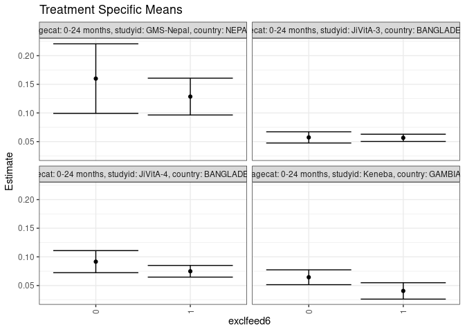

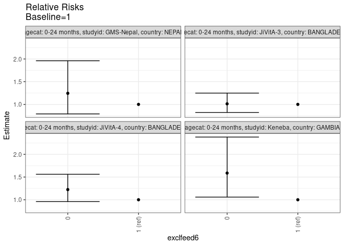

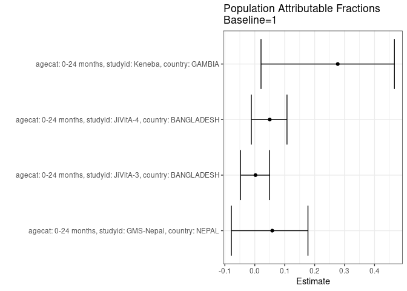

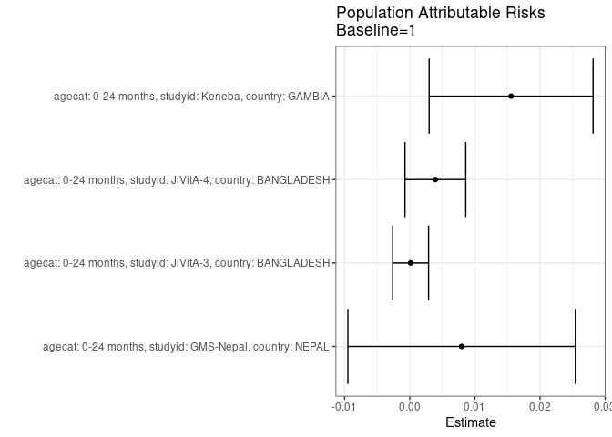

## Results Table

### Parameter: TSM

| agecat | studyid | country | intervention_level | baseline_level | estimate | ci_lower | ci_upper |
| --- | --- | --- | --- | --- | --- | --- | --- |
| 0-24 months | GMS-Nepal | NEPAL | 1 | NA | 0.1285641 | 0.0964420 | 0.1606861 |
| 0-24 months | GMS-Nepal | NEPAL | 0 | NA | 0.1599640 | 0.0992455 | 0.2206826 |
| 0-24 months | JiVitA-3 | BANGLADESH | 1 | NA | 0.0565708 | 0.0502812 | 0.0628604 |
| 0-24 months | JiVitA-3 | BANGLADESH | 0 | NA | 0.0572939 | 0.0475112 | 0.0670766 |
| 0-24 months | JiVitA-4 | BANGLADESH | 1 | NA | 0.0748778 | 0.0646849 | 0.0850707 |
| 0-24 months | JiVitA-4 | BANGLADESH | 0 | NA | 0.0916308 | 0.0723299 | 0.1109316 |
| 0-24 months | Keneba | GAMBIA | 1 | NA | 0.0405932 | 0.0263107 | 0.0548757 |
| 0-24 months | Keneba | GAMBIA | 0 | NA | 0.0644414 | 0.0514728 | 0.0774101 |

### Parameter: E(Y)

| agecat | studyid | country | intervention_level | baseline_level | estimate | ci_lower | ci_upper |
| --- | --- | --- | --- | --- | --- | --- | --- |
| 0-24 months | GMS-Nepal | NEPAL | NA | NA | 0.1365248 | 0.1081636 | 0.1648860 |
| 0-24 months | JiVitA-3 | BANGLADESH | NA | NA | 0.0566978 | 0.0514863 | 0.0619092 |
| 0-24 months | JiVitA-4 | BANGLADESH | NA | NA | 0.0788061 | 0.0697217 | 0.0878905 |
| 0-24 months | Keneba | GAMBIA | NA | NA | 0.0561586 | 0.0463537 | 0.0659635 |

### Parameter: RR

| agecat | studyid | country | intervention_level | baseline_level | estimate | ci_lower | ci_upper |
| --- | --- | --- | --- | --- | --- | --- | --- |
| 0-24 months | GMS-Nepal | NEPAL | 1 | 1 | 1.000000 | 1.0000000 | 1.000000 |
| 0-24 months | GMS-Nepal | NEPAL | 0 | 1 | 1.244236 | 0.7894611 | 1.960988 |
| 0-24 months | JiVitA-3 | BANGLADESH | 1 | 1 | 1.000000 | 1.0000000 | 1.000000 |
| 0-24 months | JiVitA-3 | BANGLADESH | 0 | 1 | 1.012782 | 0.8214333 | 1.248706 |
| 0-24 months | JiVitA-4 | BANGLADESH | 1 | 1 | 1.000000 | 1.0000000 | 1.000000 |
| 0-24 months | JiVitA-4 | BANGLADESH | 0 | 1 | 1.223737 | 0.9592174 | 1.561203 |
| 0-24 months | Keneba | GAMBIA | 1 | 1 | 1.000000 | 1.0000000 | 1.000000 |
| 0-24 months | Keneba | GAMBIA | 0 | 1 | 1.587492 | 1.0586087 | 2.380606 |

### Parameter: PAR

| agecat | studyid | country | intervention_level | baseline_level | estimate | ci_lower | ci_upper |
| --- | --- | --- | --- | --- | --- | --- | --- |
| 0-24 months | GMS-Nepal | NEPAL | 1 | NA | 0.0079608 | -0.0095083 | 0.0254298 |
| 0-24 months | JiVitA-3 | BANGLADESH | 1 | NA | 0.0001270 | -0.0026312 | 0.0028851 |
| 0-24 months | JiVitA-4 | BANGLADESH | 1 | NA | 0.0039283 | -0.0007416 | 0.0085982 |
| 0-24 months | Keneba | GAMBIA | 1 | NA | 0.0155653 | 0.0029743 | 0.0281564 |

### Parameter: PAF

| agecat | studyid | country | intervention_level | baseline_level | estimate | ci_lower | ci_upper |
| --- | --- | --- | --- | --- | --- | --- | --- |
| 0-24 months | GMS-Nepal | NEPAL | 1 | NA | 0.0583101 | -0.0783140 | 0.1776236 |
| 0-24 months | JiVitA-3 | BANGLADESH | 1 | NA | 0.0022392 | -0.0476495 | 0.0497522 |
| 0-24 months | JiVitA-4 | BANGLADESH | 1 | NA | 0.0498476 | -0.0115624 | 0.1075295 |
| 0-24 months | Keneba | GAMBIA | 1 | NA | 0.2771675 | 0.0207700 | 0.4664309 |